# Untitled

### Factor analysis

The factor loading analysis showed a suspicion that the items deemed suitable from class discussion and then filtered out with an item analysis, may be the cumulation of more than one factor in a need for control. After the items were categorized by component, a determination of these components was made. Ability items (*e.g.*, “*It feels natural for me to lead conversations when working on group projects.*”, “*I can get my way through talking to people.*”) illustrate the possible magnitude of control an individual may posses through either persuasion or a feeling of nature leadership. Items from the second component, Motivation (*e.g.*, “*When I go on a trip, I like to keep a predetermined schedule.*”, “*When things don’t go my way, I get upset.*”, “*Typically, my judgement is better than my peers*”) illustrate desires to be involved in planning and making decisions as well reactions to possible threats of losing or not gaining control. Separate analyses had not been performed with these possible subscales.

```r
fa_df <- csv %>%
  filter(name == "CON_full") %>%
  spread(item, response) %>%
  select(-id, -name, -scale, -domain)

fa <- psych::fa(fa_df, nfactors = 2, rotate = "varimax")
fa$loadings
```

```
Loadings:
   MR1    MR2
1         -0.210
2   0.214  0.565
3          0.454
4  -0.526  0.355
5          0.580
6  -0.572  0.415
7   0.153  0.529
8   0.322  0.363
9          0.138
10  0.601  0.256
11         0.472
12         0.305
13
```

[output cut: 23 more lines]

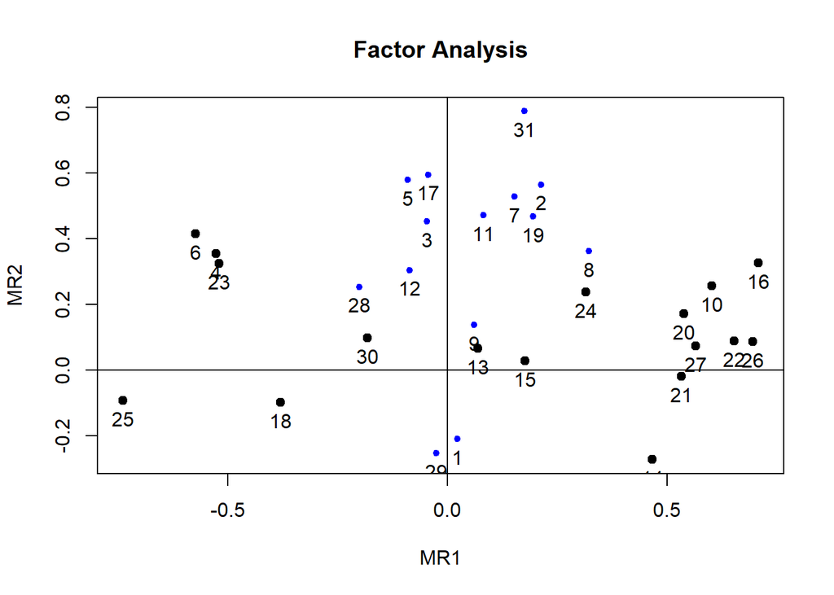

```r
plot(fa)
```